# Tutorial 1 : Data Analysis with Pandas

### In this tutorial we will explore ['cars.csv'](https://forge.scilab.org/index.php/p/rdataset/source/file/master/csv/datasets/cars.csv) dataset using basic data manipulation and visualisation functions provided by pandas library

## You will learn :

- To read dataset using pandas
- To get quick summary of data
- To manipulate dataset columns for data processing
- To plot the porcessed data for insights

## We assume you know:

- Basic python
- Basic understanding of plots

## Resources:

- [Pandas Documentation](https://pandas.pydata.org/pandas-docs/stable/)
- [Cars Dataset](https://forge.scilab.org/index.php/p/rdataset/source/file/master/csv/datasets/cars.csv)
- Find source code of this tutorial [here](https://github.com/sanketd11/DataScienceClub)

# Let's Begin.....

### What is Pandas?

Pandas is one of the most powerfull libraries that are used for data analysis in python. Pandas provide two primary data structures Series (1- dimentional) and Dataframe( 2 dimensional) which can be used to express the data intuitively and perform fast operations. Pandas is built on top of [**numpy**](http://www.numpy.org/) which is another powerful and popular library used in python for scientific computations.

### Import Library

Import the pandas library. Here I renamed it to 'pd' just for the ease of use. Make sure you don't get errors in import

```python
import pandas as pd

from matplotlib import pyplot as plt # required for plots
plt.style.use= 'default'# To display plots
```

## Read Dataset

Following are some of the functions available in pandas for reading a dataset

- **read_csv()** (Press 'Shift+tab' to see the function arguments )
  - filepath
  - sep
  - names
  - parse_dates
  - index_col
- read_excel()
- read_json()
- read_pickle()
- read_sql()

```python
df=pd.read_csv('cars.csv', sep=';')
```

## Know Your Dataset

We can use following functions to get basic understanding of the dataset: (Assume 'df' contains data)

- *df.shape*
- *df.columns*
- *df.head()*
- *df.tail()*
- *df.describe()*

Let's look at these one by one

- #### df.shape

Retrieves Shape of the dataset

```python
df.shape
```

```
(406, 9)
```

- #### df.columns

Retrive the column names from data

```python
df.columns.tolist()
```

```
['Car',
 'MPG',
 'Cylinders',
 'Displacement',
 'Horsepower',
 'Weight',
 'Acceleration',
 'Model',
 'Origin']
```

- #### df.head(n)

```python
df.head()
```

|  | Car | MPG | Cylinders | Displacement | Horsepower | Weight | Acceleration | Model | Origin |
| --- | --- | --- | --- | --- | --- | --- | --- | --- | --- |
| 0 | Chevrolet Chevelle Malibu | 18.0 | 8 | 307.0 | 130.0 | 3504.0 | 12.0 | 70 | US |
| 1 | Buick Skylark 320 | 15.0 | 8 | 350.0 | 165.0 | 3693.0 | 11.5 | 70 | US |
| 2 | Plymouth Satellite | 18.0 | 8 | 318.0 | 150.0 | 3436.0 | 11.0 | 70 | US |
| 3 | AMC Rebel SST | 16.0 | 8 | 304.0 | 150.0 | 3433.0 | 12.0 | 70 | US |
| 4 | Ford Torino | 17.0 | 8 | 302.0 | 140.0 | 3449.0 | 10.5 | 70 | US |

- #### df.tail(n)

```python
df.tail()
```

|  | Car | MPG | Cylinders | Displacement | Horsepower | Weight | Acceleration | Model | Origin |
| --- | --- | --- | --- | --- | --- | --- | --- | --- | --- |
| 401 | Ford Mustang GL | 27.0 | 4 | 140.0 | 86.0 | 2790.0 | 15.6 | 82 | US |
| 402 | Volkswagen Pickup | 44.0 | 4 | 97.0 | 52.0 | 2130.0 | 24.6 | 82 | Europe |
| 403 | Dodge Rampage | 32.0 | 4 | 135.0 | 84.0 | 2295.0 | 11.6 | 82 | US |
| 404 | Ford Ranger | 28.0 | 4 | 120.0 | 79.0 | 2625.0 | 18.6 | 82 | US |
| 405 | Chevy S-10 | 31.0 | 4 | 119.0 | 82.0 | 2720.0 | 19.4 | 82 | US |

- #### df.describe()

Generate Summary statistics form the dataset

```python
df.describe()
```

|  | MPG | Cylinders | Displacement | Horsepower | Weight | Acceleration | Model |
| --- | --- | --- | --- | --- | --- | --- | --- |
| count | 406.000000 | 406.000000 | 406.000000 | 406.000000 | 406.000000 | 406.000000 | 406.000000 |
| mean | 23.051232 | 5.475369 | 194.779557 | 103.529557 | 2979.413793 | 15.519704 | 75.921182 |
| std | 8.401777 | 1.712160 | 104.922458 | 40.520659 | 847.004328 | 2.803359 | 3.748737 |
| min | 0.000000 | 3.000000 | 68.000000 | 0.000000 | 1613.000000 | 8.000000 | 70.000000 |
| 25% | 17.000000 | 4.000000 | 105.000000 | 75.000000 | 2226.500000 | 13.700000 | 73.000000 |
| 50% | 22.350000 | 4.000000 | 151.000000 | 93.500000 | 2822.500000 | 15.500000 | 76.000000 |
| 75% | 29.000000 | 8.000000 | 302.000000 | 129.000000 | 3618.250000 | 17.175000 | 79.000000 |
| max | 46.600000 | 8.000000 | 455.000000 | 230.000000 | 5140.000000 | 24.800000 | 82.000000 |

- **df.isnull()**

This function checks if there are any missing values in the dataset. Returns true if the value is missing. The missing values in the dataset need to be handled carefully in order to maintain consistancy in data

```python
df.isnull()

# any() returns true if atleast one of the values is truthy
df.isnull().any()
```

```
Car             False
MPG             False
Cylinders       False
Displacement    False
Horsepower      False
Weight          False
Acceleration    False
Model           False
Origin          False
dtype: bool
```

## Data Manipulation

Data manipulation is required to process the data in order to get hidden relationships beteen the features. Following are some basic functions used for data manipulation in pandas

```python
# Get Column Values
# Syntax: df[column_name]
# Return: Column values
df["Origin"][:10]
```

```
0    US
1    US
2    US
3    US
4    US
5    US
6    US
7    US
8    US
9    US
Name: Origin, dtype: object
```

```python
# Get multiple columns
# Syntax: df[list of column_names]
# Return: dataframe of specified columns

df[["Car", "Model", "Origin"]]

# Another way
col_list=["Car", "Model", "Origin"]
df[col_list]
```

|  | Car | Model | Origin |
| --- | --- | --- | --- |
| 0 | Chevrolet Chevelle Malibu | 70 | US |
| 1 | Buick Skylark 320 | 70 | US |
| 2 | Plymouth Satellite | 70 | US |
| 3 | AMC Rebel SST | 70 | US |
| 4 | Ford Torino | 70 | US |
| 5 | Ford Galaxie 500 | 70 | US |
| 6 | Chevrolet Impala | 70 | US |
| 7 | Plymouth Fury iii | 70 | US |
| 8 | Pontiac Catalina | 70 | US |
| 9 | AMC Ambassador DPL | 70 | US |
| 10 | Citroen DS-21 Pallas | 70 | Europe |
| 11 | Chevrolet Chevelle Concours (sw) | 70 | US |
| 12 | Ford Torino (sw) | 70 | US |
| 13 | Plymouth Satellite (sw) | 70 | US |
| 14 | AMC Rebel SST (sw) | 70 | US |
| 15 | Dodge Challenger SE | 70 | US |
| 16 | Plymouth 'Cuda 340 | 70 | US |
| 17 | Ford Mustang Boss 302 | 70 | US |
| 18 | Chevrolet Monte Carlo | 70 | US |
| 19 | Buick Estate Wagon (sw) | 70 | US |
| 20 | Toyota Corolla Mark ii | 70 | Japan |
| 21 | Plymouth Duster | 70 | US |
| 22 | AMC Hornet | 70 | US |
| 23 | Ford Maverick | 70 | US |
| 24 | Datsun PL510 | 70 | Japan |
| 25 | Volkswagen 1131 Deluxe Sedan | 70 | Europe |
| 26 | Peugeot 504 | 70 | Europe |
| 27 | Audi 100 LS | 70 | Europe |
| 28 | Saab 99e | 70 | Europe |
| 29 | BMW 2002 | 70 | Europe |
| ... | ... | ... | ... |
| 376 | Chevrolet Cavalier Wagon | 82 | US |
| 377 | Chevrolet Cavalier 2-door | 82 | US |
| 378 | Pontiac J2000 SE Hatchback | 82 | US |
| 379 | Dodge Aries SE | 82 | US |
| 380 | Pontiac Phoenix | 82 | US |
| 381 | Ford Fairmont Futura | 82 | US |
| 382 | AMC Concord DL | 82 | US |
| 383 | Volkswagen Rabbit l | 82 | Europe |
| 384 | Mazda GLC Custom l | 82 | Japan |
| 385 | Mazda GLC Custom | 82 | Japan |
| 386 | Plymouth Horizon Miser | 82 | US |
| 387 | Mercury Lynx l | 82 | US |
| 388 | Nissan Stanza XE | 82 | Japan |
| 389 | Honda Accord | 82 | Japan |
| 390 | Toyota Corolla | 82 | Japan |
| 391 | Honda Civic | 82 | Japan |
| 392 | Honda Civic (auto) | 82 | Japan |
| 393 | Datsun 310 GX | 82 | Japan |
| 394 | Buick Century Limited | 82 | US |
| 395 | Oldsmobile Cutlass Ciera (diesel) | 82 | US |
| 396 | Chrysler Lebaron Medallion | 82 | US |
| 397 | Ford Grenada l | 82 | US |
| 398 | Toyota Celica GT | 82 | Japan |
| 399 | Dodge Charger 2.2 | 82 | US |
| 400 | Chevrolet Camaro | 82 | US |
| 401 | Ford Mustang GL | 82 | US |
| 402 | Volkswagen Pickup | 82 | Europe |
| 403 | Dodge Rampage | 82 | US |
| 404 | Ford Ranger | 82 | US |
| 405 | Chevy S-10 | 82 | US |

406 rows × 3 columns

```python
# Maths with data frame columns. The mathematical operation applies to all the rows of selected rows
# Multiplication
df["Weight"]*0.001
df[["MPG", "Displacement"]]*2

#Division
df["MPG"]/2
df[["MPG", "Displacement"]]/2

#Comparisons
df["MPG"][:10] >30 # returns True for if MPG value > 10 otherwise returns False
```

```
0    False
1    False
2    False
3    False
4    False
5    False
6    False
7    False
8    False
9    False
Name: MPG, dtype: bool
```

```python
#Indexing using comparison
df[df["MPG"]>40]

#Get the columns with condition on any column
df[df["MPG"]>40][["Weight","Car"]]
```

|  | Weight | Car |
| --- | --- | --- |
| 251 | 1985.0 | Volkswagen Rabbit Custom Diesel |
| 316 | 2144.0 | Volkswagen Rabbit |
| 329 | 2110.0 | Mazda GLC |
| 331 | 2110.0 | Datsun 210 |
| 332 | 2085.0 | Volkswagen Rabbit C (Diesel) |
| 333 | 2335.0 | Volkswagen Dasher (diesel) |
| 336 | 1850.0 | Honda Civic 1500 gl |
| 337 | 1835.0 | Renault Lecar Deluxe |
| 402 | 2130.0 | Volkswagen Pickup |

```python
# Slicing Dataframe
df[1:5]
df["MPG"][:5]
```

```
0    18.0
1    15.0
2    18.0
3    16.0
4    17.0
Name: MPG, dtype: float64
```

```python
# Group the data according to one of the categorical columns
# In cars data set Cylinders, Model, Origin are the categorical variables

data=df.groupby("Origin") # returns pandas object. Can use list of columns
list(data)

data=df.groupby("Origin")["MPG"].mean() # returns pandas object. Can use list of columns
list(data)
```

```
[26.745205479452057, 30.450632911392397, 19.688188976377948]
```

```python
# Data Aggregation methods (Can be used independently or along with 'groupby')

#Mean
df.mean()  #Returns mean value of all the columns

#Max
df.max()   #Returns max value of all the columns

#Min
df.min()   #Returns min value of all the columns

#Count
df.count() # Returns the count of column values

#sum
df.sum()  # Returns the sum of all the columns
```

```
Car             Chevrolet Chevelle MalibuBuick Skylark 320Plym...
MPG                                                        9358.8
Cylinders                                                    2223
Displacement                                              79080.5
Horsepower                                                  42033
Weight                                                1.20964e+06
Acceleration                                                 6301
Model                                                       30824
Origin          USUSUSUSUSUSUSUSUSUSEuropeUSUSUSUSUSUSUSUSUSJa...
dtype: object
```

```python
# Drop columns that are not required
dfNew=df.drop("Origin", axis=1)
print(df.columns.tolist())
print(dfNew.columns.tolist())
```

```
['Car', 'MPG', 'Cylinders', 'Displacement', 'Horsepower', 'Weight', 'Acceleration', 'Model', 'Origin']
['Car', 'MPG', 'Cylinders', 'Displacement', 'Horsepower', 'Weight', 'Acceleration', 'Model']
```

## Data Visualization

Pandas provide several plot options that we can use to visualize our dataset. Visualisations help to understand the relations between the various features from the dataset. Following are some of the plot options that we can use.

- *df.plot.**

Following plot options are also available to be used with pandas dataframe

- df.plot.area
- df.plot.barh
- df.plot.density
- df.plot.hist
- df.plot.line
- df.plot.scatter
- df.plot.bar
- df.plot.box
- df.plot.hexbin
- df.plot.kde
- df.plot.pie

#### For more details on plots visit: [Pandas Visualization](https://pandas.pydata.org/pandas-docs/stable/visualization.html)

## Analysis

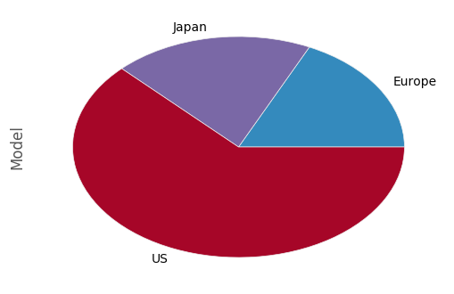

```python
df.groupby("Origin")["Model"].count().plot.pie()
```

### The above pie-chart shows that mejority of the models are originated in US

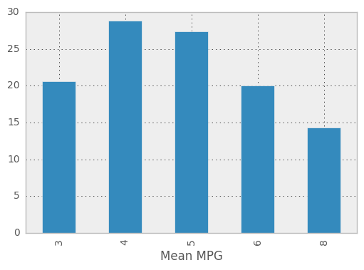

```python
df.groupby("Cylinders")["MPG"].mean().plot.bar()
plt.xlabel("Mean MPG")
```

### The above bar chart representation shows that cars having 4 and 5 cylinders gave the highest mean MPG compared to others

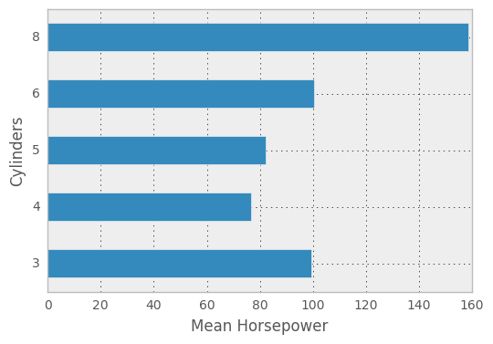

```python
df.groupby("Cylinders")["Horsepower"].mean().plot.barh()
plt.xlabel("Mean Horsepower")
```

### The above chart clearly shows that the cars with 8 cylinders produced highest horspower compared to others

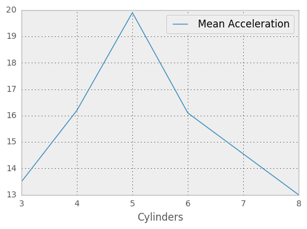

```python
df.groupby("Cylinders")["Acceleration"].median().plot.line()
plt.legend(["Mean Acceleration"])
```

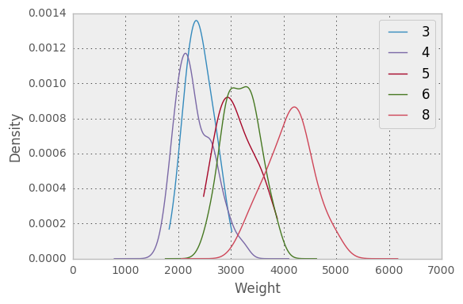

```python
df.groupby("Cylinders")["Weight"].plot.kde()
plt.legend()
plt.xlabel("Weight")
```

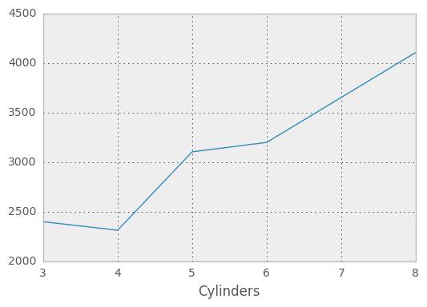

```python
df.groupby("Cylinders")["Weight"].mean().plot.line()
```

### The above plots show relation ship between weight and the cylinders. It shows that the cars with higher number of cylinders will weigh more than the one with less number of cylinders

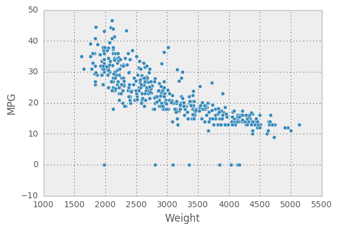

```python
df.plot.scatter(y="MPG" ,x="Weight")
```

### The above chart shows the relationship between MPG and Weight of the car. We can see that MPG tends to decrease as Weight of the vehicle increases

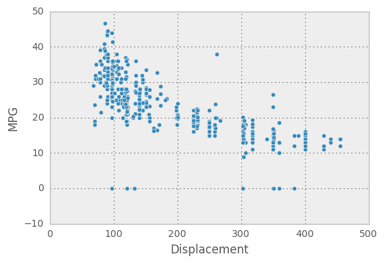

```python
df.plot.scatter(x="Displacement" ,y="MPG")
```

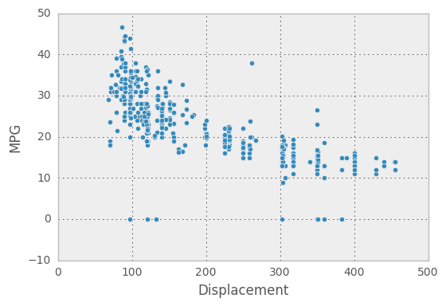

```python
df.plot.scatter(y='MPG',x='Displacement')
```

### The above chart shows the relationship between MPG and Displacement. We can see that MPG tends to decrease with increase in Displacement

## Some more functions for visualization:

### histogram plot for all numerical features

- *df.hist()*

[output not shown]

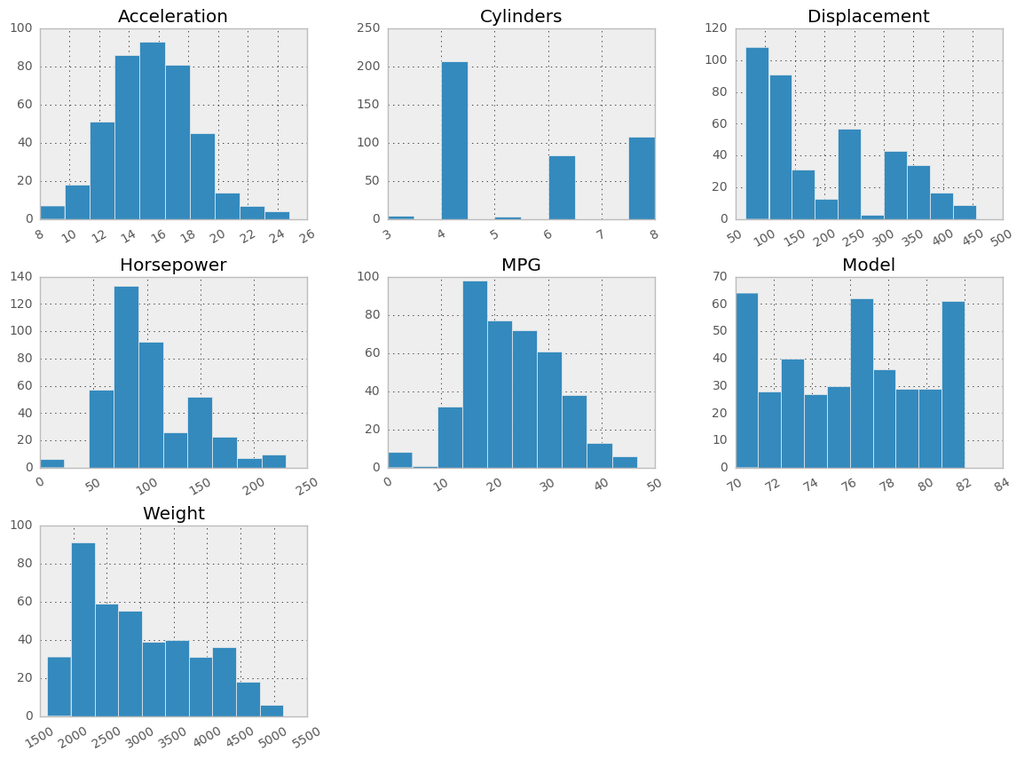

```python
df.hist(xrot=30,figsize=(14,10))
```

### Histogram plots for all numerical variables grouped by categorical variable "Origin":

```
Origin
Europe    [[Axes(0.125,0.684722;0.215278x0.215278), Axes...
Japan     [[Axes(0.125,0.684722;0.215278x0.215278), Axes...
US        [[Axes(0.125,0.684722;0.215278x0.215278), Axes...
dtype: object
```

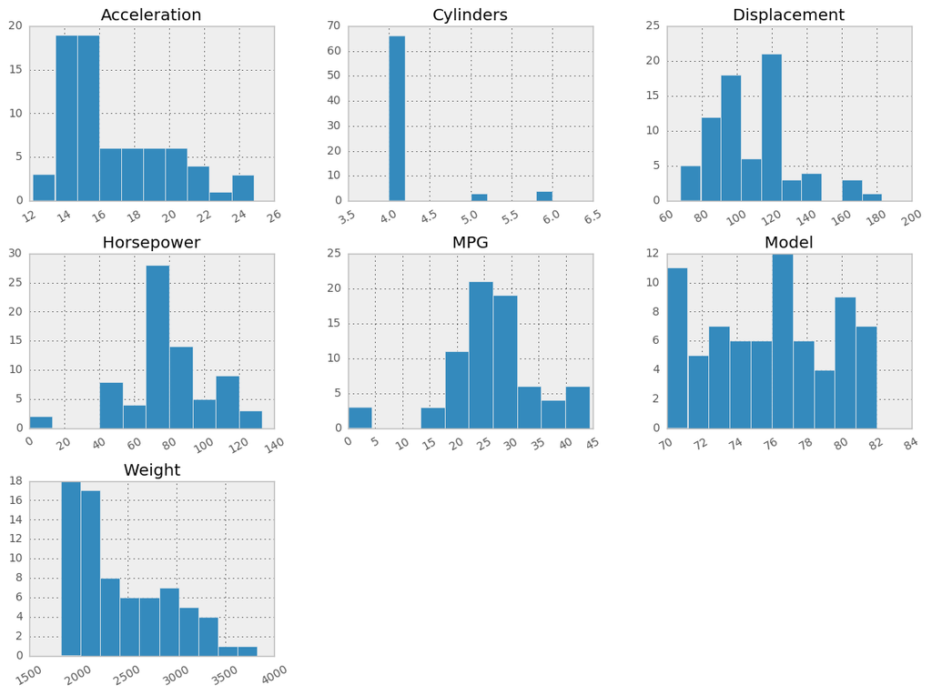

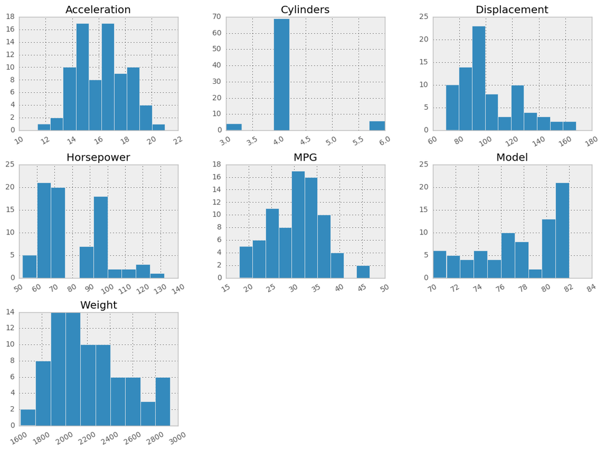

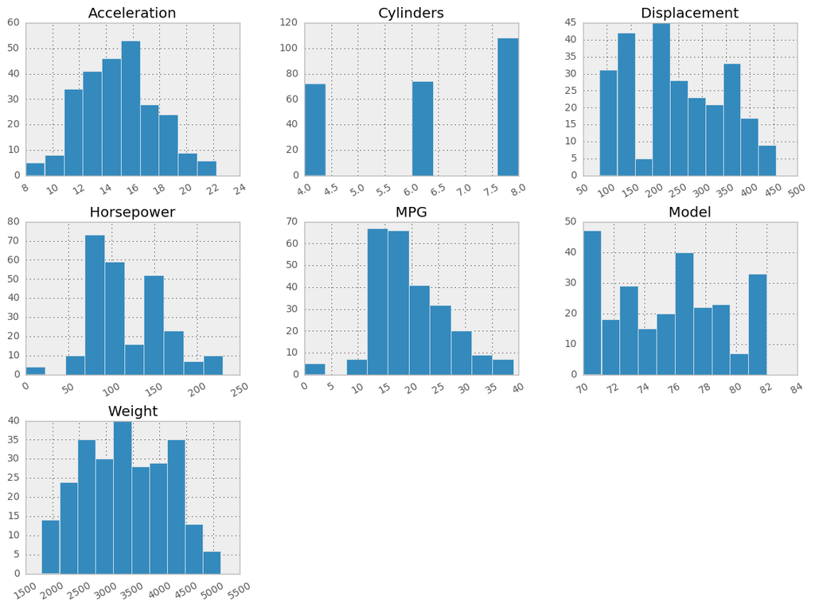

```python
df.groupby("Origin").hist(xrot=30,figsize=(14,10))
```

### Combined representation of all the numerical features using scatter plots (one for each combination of 2 variables) and histogram plots individual variables

- *pd.scatter_matrix(df)*

[output not shown]

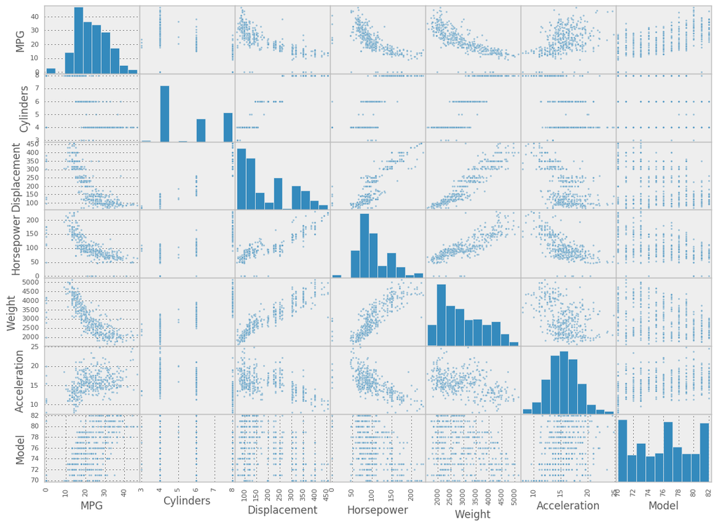

```python
pd.scatter_matrix(df,figsize=(14,10))
```